# A Text Predictor Application

Pier Lorenzo Paracchini  
28.05.2016

### The Challenge

### Developing a prediction model for next word

Around the world, people are spending an increasing amount of time on their mobile devices for email, social networking, banking and a whole range of other activities. But typing on mobile devices can be a serious pain.

When someone, for example, types **“I went to the”** the application should **presents at least three options** for what the **next word might be** and it should be able to run as a mobile/ web app in a **responsive** way.

* The **challenge** is related to the **“Data Science Capstone” module** of the **Data Science Specialization** (Johns Hopkins University, Coursera)

### The Supporting Data

The data to used for building the **predictive model** is coming from the **[HC corpora](http://www.corpora.heliohost.org/)**. The **corpora** is a collection of 3 different **corpus** (twitter, news and blogs) with the aim of getting a varied and comprehensive corpus of current use of the languages.

The **original corpora**, with focus only on the **english language** (*en_US*), includes:

- 2.360.148 tweets
- 1.010.242 news
- 899.288 blogs

* More information about the original corpora can be found in the [milestone report](https://rpubs.com/pparacch/177065)

### The Ingestion Process

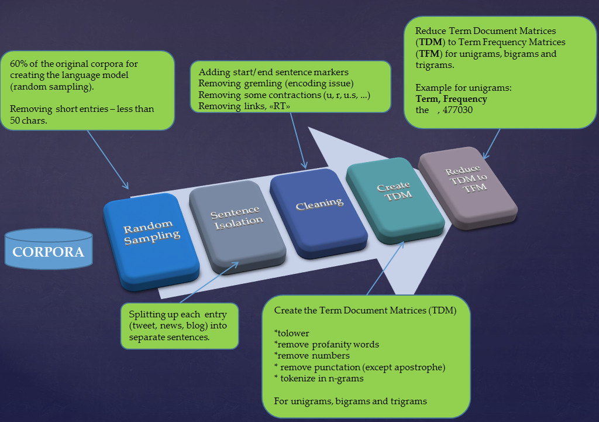

* Some more information about the ingestion process can be found in the [ingestion report](http://rpubs.com/pparacch/184463)

### The Language Model - Creation

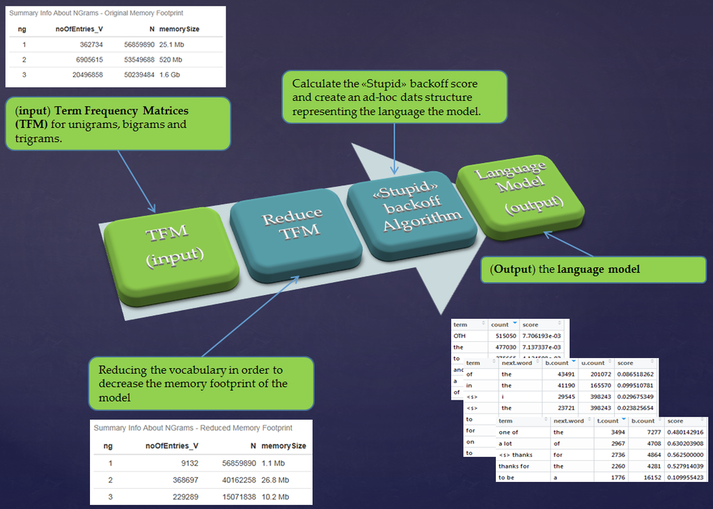

* Some more information about the strategy around ngrams size reduction can be found in the [reduction report](https://rpubs.com/pparacch/184468)

### The Language Model: "Stupid" backoff

Different models have been implemented: n-grams (n = 1,2,3), linear interpolation (n-grams, n = 1,2,3) with Good Turing smoothing and “Stupid” backoff (with no discount).

The model evaluations has been done using the **perplexity** measurement and an **ad-hoc testing dataset** (around 40 sentences). The “Stupid” Backoff model was the one able to minimize the **perplexity** measurement.

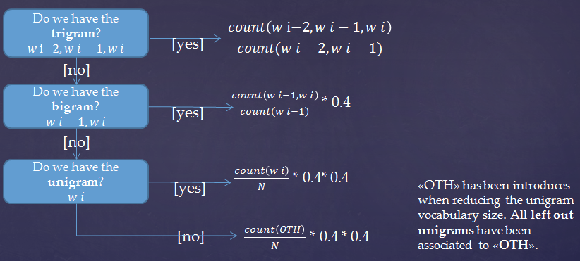

### The Application - Basic Usage

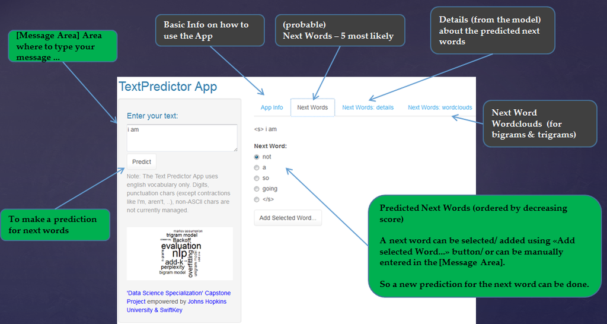

[TextPredictor App](https://pparacch.shinyapps.io/TextPredictorApplication/) at **shiny.app.io**, [Capstone Project Repository](https://github.com/pparacch/CapstoneProjectDataScienceSpecialization) at **github.com**

### Kudos

I would like to express my deepest appreciation to the **great professors** of **Johns Hopkins University** for making this specialization available at **Coursera**. Special kudos to all of the participants of this Capstone project for the valuable discussions, tips and tricks made available in the forums. If you want to keep in contact please just add [my LinkedIn profile](https://www.linkedin.com/in/pierlorenzoparacchini) to your **LinkedIn** connections.

It has been a **long and challenging journey** with ups and downs, **worth every single moment**. **Thank you to you all!!**